# Personal de Enfermería y Cuidados

Alicia Perdices Guerra

3 de mayo, 2021

#### **1.PROCESAMIENTO DE LOS DATOS.**

- En primer lugar leemos el fichero:

```r
enfermeria<-read.csv("C:/temp/Personal_Enfermeria_Cuidados.csv",sep= ",")
```

- Realicemos una breve inspección de los datos

```r
str(enfermeria)
```

```
## 'data.frame':    17100 obs. of  7 variables:
##  $ TIME              : int  2010 2010 2010 2010 2010 2010 2010 2010 2010 2010 ...
##  $ GEO               : Factor w/ 38 levels "Albania","Austria",..: 3 3 3 3 3 3 3 3 3 3 ...
##  $ UNIT              : Factor w/ 3 levels "Inhabitants per ...",..: 2 2 2 2 2 2 2 2 2 2 ...
##  $ WSTATUS           : Factor w/ 3 levels "Licensed to practice",..: 2 2 2 2 2 3 3 3 3 3 ...
##  $ ISCO08            : Factor w/ 5 levels "Nurses","Nurses and midwives",..: 3 2 5 1 4 3 2 5 1 4 ...
##  $ Value             : Factor w/ 5564 levels ":","1 000.23",..: 1 955 1 837 1 2294 1380 1 1284 1 ...
##  $ Flag.and.Footnotes: Factor w/ 9 levels "","b","bde","be",..: 1 1 1 7 1 1 1 1 7 1 ...
```

```r
colnames(enfermeria) #Nombre de las variables
```

```
## [1] "TIME"               "GEO"                "UNIT"
## [4] "WSTATUS"            "ISCO08"             "Value"
## [7] "Flag.and.Footnotes"
```

```r
nrow(enfermeria) #Número de registros
```

```
## [1] 17100
```

```r
ncol(enfermeria) #Número de variables
```

```
## [1] 7
```

*Observamos las siguientes variables:

- **TIME**: variable cuantitativa. Indica el año en el que se ha realizado la medida, en este caso el valor de la variable “Value”. Se ha cargado bien como número entero.
- **GEO**: variable cualitativa. Indica el país o región en el que se ha realizado la medida.Se ha cargado bien como factor.
- **UNIT**: variable cualitativa. Indica la medida de la variable valor.Se ha cargado bien como factor.
- **WSTATUS**: variable cualitativa. Indica el estatus laboral del personal de enfermeria y cuidados.
- **ISCO08**: Variable cualitativa. Indica si la variable “Value” se refiere solo a enfermero/as,matronas etc.
- **Value**: Variable cuantitativa. Indica el número y ratio de profesionales de enfermería por países.
- **Fal.and.footnotes**. Notas sobre etiquetas. Eliminamos esta columna.

*Años de las mediciones:

```r
unique(enfermeria$TIME)
```

```
##  [1] 2010 2011 2012 2013 2014 2015 2016 2017 2018 2019
```

*Paises:

```r
unique(enfermeria$GEO)
```

```
##  [1] Belgium
##  [2] Bulgaria
##  [3] Czechia
##  [4] Denmark
##  [5] Germany (until 1990 former territory of the FRG)
##  [6] Estonia
##  [7] Ireland
##  [8] Greece
##  [9] Spain
## [10] France
## [11] France (metropolitan)
## [12] Croatia
## [13] Italy
## [14] Cyprus
## [15] Latvia
```

[output cut: 24 more lines]

*Unidad de las mediciones:

```r
unique(enfermeria$UNIT)
```

```
## [1] Number                           Inhabitants per ...
## [3] Per hundred thousand inhabitants
## Levels: Inhabitants per ... Number Per hundred thousand inhabitants
```

*Variable que indica el estatus laboral del personal de enfermería.

```r
unique(enfermeria$WSTATUS)
```

```
## [1] Practising            Professionally active Licensed to practice
## Levels: Licensed to practice Practising Professionally active
```

*Variable que indica cómo agrupamos el personal de enfermería para las mediciones.

```r
unique(enfermeria$ISCO08)
```

```
## [1] Nurses, midewives, health care assistants and home-based personal care workers
## [2] Nurses and midwives
## [3] Nursing professionals and midwives
## [4] Nurses
## [5] Nursing professionals
## 5 Levels: Nurses ... Nursing professionals and midwives
```

- Eliminamos la columna Fal.and.footnotes.

```r
enfermeria<-enfermeria[,-7]
```

- Tendríamos que convertir la columna Value a numérico porque se ha cargado como factor y es erróneo. El resto de variables tienen el tipo correcto.

```r
enfermeria$Value<-as.character(enfermeria$Value)
enfermeria$Value<-(gsub(',','.',enfermeria$Value) )
enfermeria$Value<-(gsub(' ','',enfermeria$Value) )
enfermeria$Value<-as.numeric(enfermeria$Value)
```

- Comprobamos que valores tenemos en la columna **Value**:

```r
table(enfermeria$Value, useNA = "ifany")
```

[output not shown]

[output cut: 1536 more lines]

[output not shown]

- Observamos que tenemos **9347 valores perdidos**.Guardamos en la variable **idx** los índices de los registros con valores **NA** de la variable **Value**.

```r
idx<-which(is.na(enfermeria$Value))
length(idx)
```

```
## [1] 9347
```

- Grafiquemos la información que contiene la variable **Value**

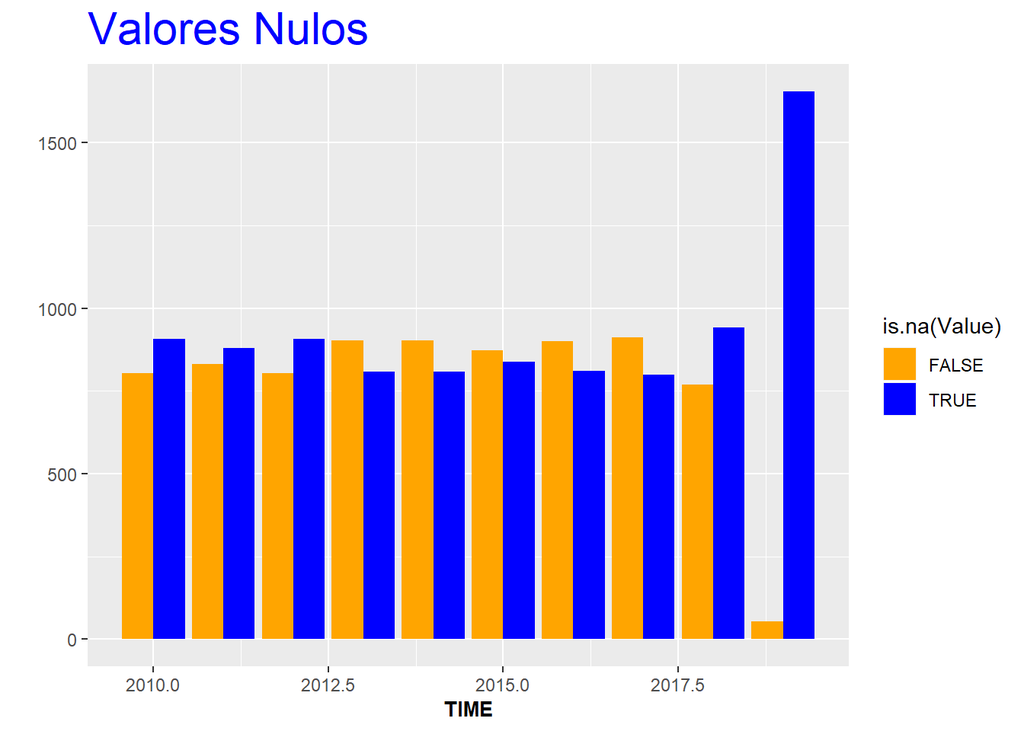

```r
library(ggplot2)
library(scales)
g = ggplot(enfermeria, aes(TIME, fill=is.na(Value)) ) +
labs(title = "Valores Nulos")+ylab("") +
theme(plot.title = element_text(size = rel(2), colour = "blue"))

g+geom_bar(position="dodge") + scale_fill_manual(values = alpha(c("orange", "blue"), 1)) +
theme(axis.title.x = element_text(face="bold", size=10))
```

- En caso de detectar algún valor anómalo (en nuestro caso los NAS) en las variables tendríamos que realizar una imputación de esos valores o bien sustituyéndolos por la media o usando el algoritmo KNN ( k-Nearest Neighbour) con los 3 vecinos más cercanos usando la distancia que consideremos, en este caso usaremos Gower(Mediana), por ser una medida más robusa frente a extremos.

```r
library(VIM)
output<-kNN(enfermeria, variable=c("Value"),k=3)
enfermeria<-output
```

- Comprobamos que no tenemos valores nulos después de la imputación

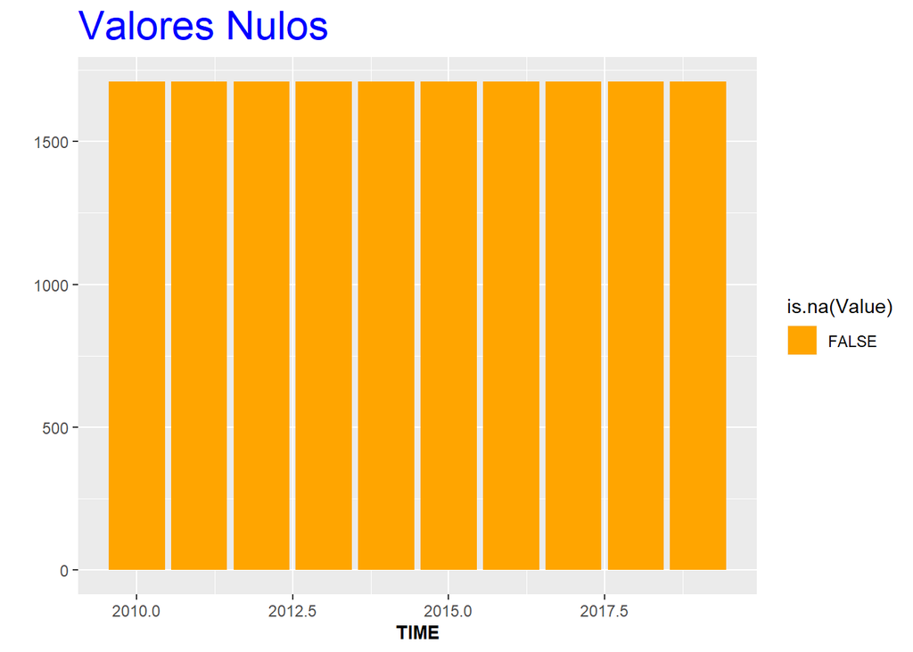

```r
g = ggplot(enfermeria, aes(TIME, fill=is.na(Value)) ) +
labs(title = "Valores Nulos")+ylab("") +
theme(plot.title = element_text(size = rel(2), colour = "blue"))

g+geom_bar(position="dodge") + scale_fill_manual(values = alpha(c("orange", "blue"), 1)) +
theme(axis.title.x = element_text(face="bold", size=10))
```

- Con el siguiente gráfico, observaremos que la variable **Value** tiene outliers o valores extremos

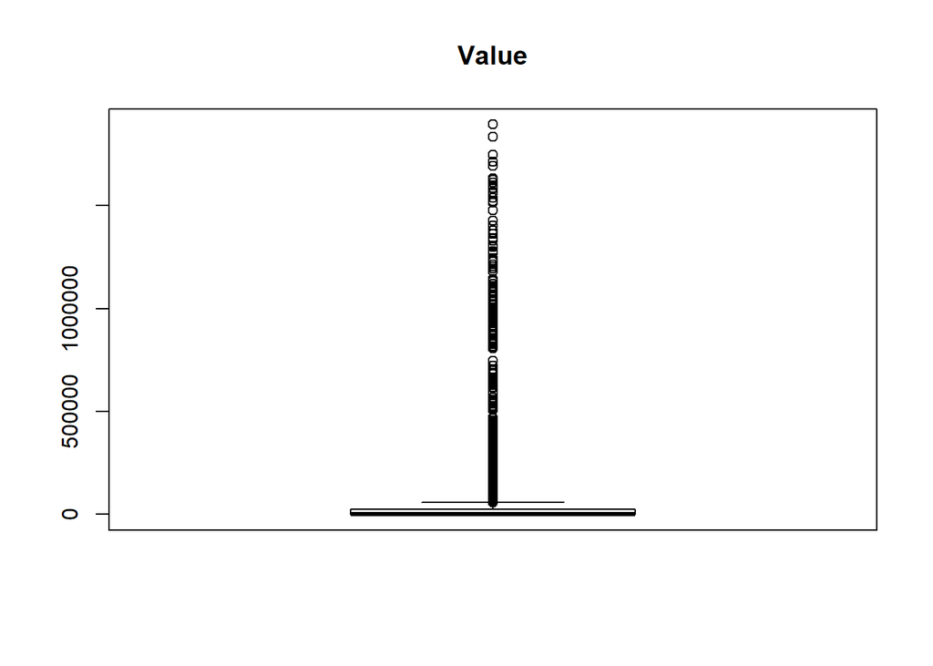

```r
boxplot(enfermeria$Value, main="Value")
```

- Por otro lado, revisamos para el resto de columnas si tenemos valores NA.(desconocidos o perdidos)

```r
table(enfermeria$TIME, useNA = "ifany")
```

```
##
## 2010 2011 2012 2013 2014 2015 2016 2017 2018 2019
## 1710 1710 1710 1710 1710 1710 1710 1710 1710 1710
```

```r
table(enfermeria$GEO, useNA = "ifany")
```

```
##
##                                          Albania
##                                              450
##                                          Austria
##                                              450
##                                          Belgium
##                                              450
##                                         Bulgaria
##                                              450
##                                          Croatia
##                                              450
##                                           Cyprus
##                                              450
##                                          Czechia
##                                              450
##                                          Denmark
##                                              450
##                                          Estonia
##                                              450
##                                          Finland
##                                              450
##                                           France
##                                              450
##                            France (metropolitan)
##                                              450
## Germany (until 1990 former territory of the FRG)
##                                              450
##                                           Greece
##                                              450
##                                          Hungary
##                                              450
##                                          Iceland
##                                              450
##                                          Ireland
##                                              450
##                                            Italy
##                                              450
##                                           Latvia
##                                              450
##                                    Liechtenstein
```

[output cut: 22 more lines]

```
##                                              450
##                                         Slovakia
##                                              450
##                                         Slovenia
##                                              450
##                                            Spain
##                                              450
##                                           Sweden
##                                              450
##                                      Switzerland
##                                              450
##                                           Turkey
##                                              450
##                                   United Kingdom
##                                              450
```

```r
table(enfermeria$UNIT, useNA = "ifany")
```

```
##
##              Inhabitants per ...                           Number
##                             5700                             5700
## Per hundred thousand inhabitants
##                             5700
```

```r
table(enfermeria$WSTATUS, useNA = "ifany")
```

```
##
##  Licensed to practice            Practising Professionally active
##                  5700                  5700                  5700
```

```r
table(enfermeria$ISCO08, useNA = "ifany")
```

```
##
##                                                                         Nurses
##                                                                           3420
##                                                            Nurses and midwives
##                                                                           3420
## Nurses, midewives, health care assistants and home-based personal care workers
##                                                                           3420
##                                                          Nursing professionals
##                                                                           3420
##                                             Nursing professionals and midwives
##                                                                           3420
```

Observamos que no existen ahora valores perdidos después de la imputación.La suma de las cantidades de cada variable, suman el total.

- Finalmente, creamos un fichero con toda la información corregida.

```r
write.csv(enfermeria, file="Personal_Enfermeria_Cuidados_clean.csv", row.names = FALSE)
```